# Why polynomials?

- They are easy to compute (addition, multiplication, exponentiation)
- They are easy to differentiate and integrate (calculus)
- With enough terms, a polynomial can closely approximate any other curve.

# Interpolation

- Imagine you collected the following temperature vs time data by measuring the temperature every hour for 12 hours:

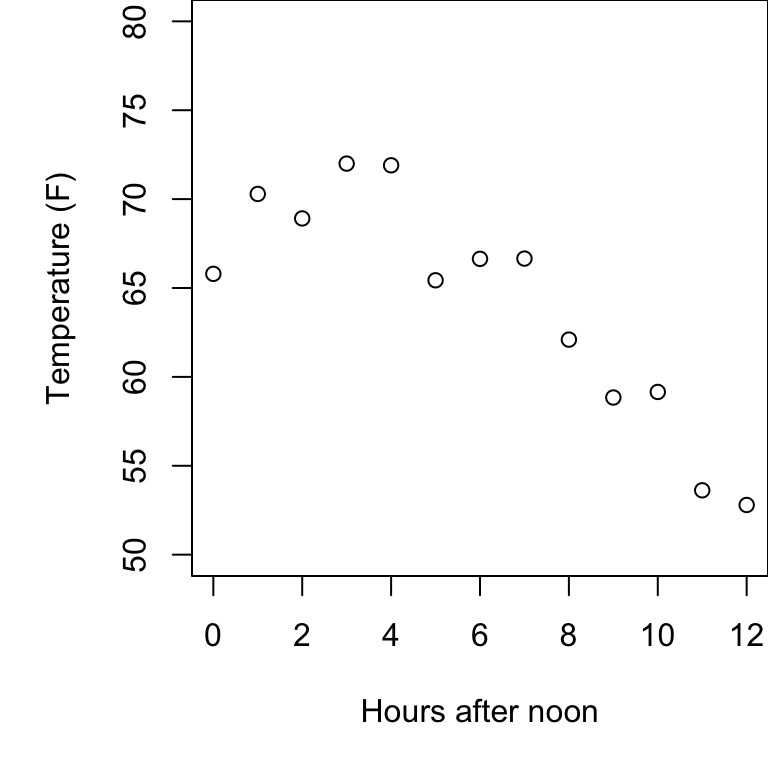

Now, someone wants you to estimate what the temperature was at 4:30 PM. You have a few choices for how to approach this.

# Piecewise linear interpolation

- You could connect neighboring points with straight lines. This is a “piecewise function”.

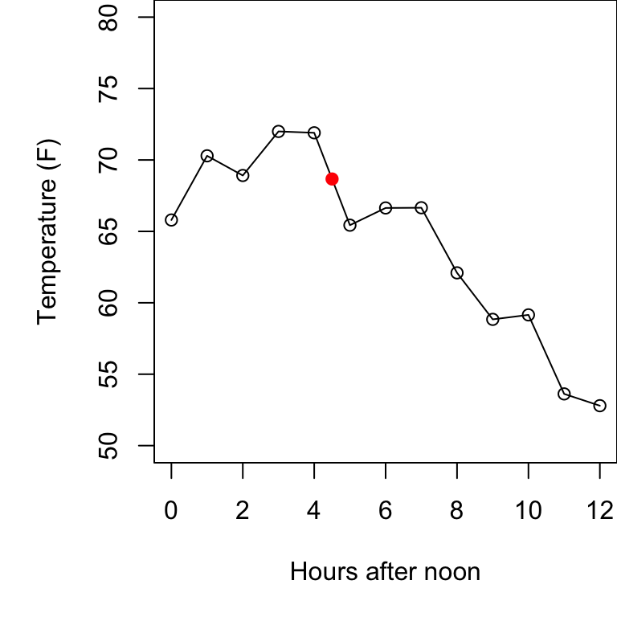

- In this case, we are simply finding the average of the temperatures at 4:00 PM and 5:00 PM.

# Lagrange polynomial

- It is possible to force a polynomial through all of those points. Since there are 13 points, it will probably need to be a degree-12 polynomial.

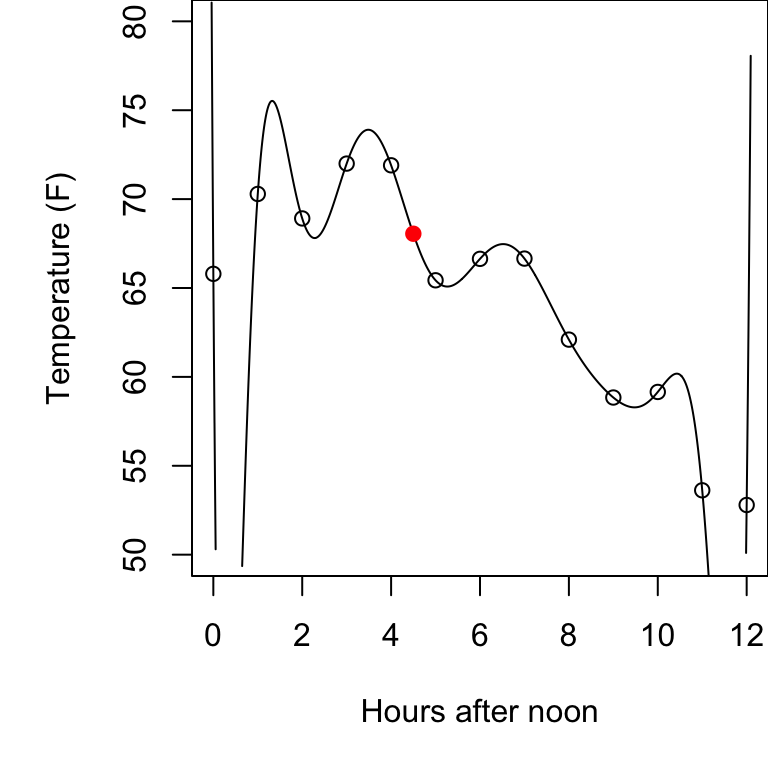

65.7965329326132 - 349.451768993086*x + 1043.34164818759*x^2 - 1252.26338289752*x^3 + 820.242133125823*x^4 - 330.992216292582*x^5 + 87.474554083205*x^6 - 15.6056426506097*x^7 + 1.89485584650577*x^8 - 0.154482529570821*x^9 + 0.00809738980113456*x^10 - 0.000246671991007203*x^11 + 0.00000332033582255327*x^12

Notice this “blows up” a bit. In science, we would call this **overfitting**. Typically, we wish to smooth out the data, because the data come with noise.

# Regression

Instead of using a 12-degree polynomial that hits all points exactly, we can use a lower-degree polynomial that gets close to the points.

Technically (almost always) we minimize the sum of the squared residuals (the vertical distance from point to curve).

Typically, one starts with linear regression, and adds higher degrees until no benefit of extra terms.

- Linear regression

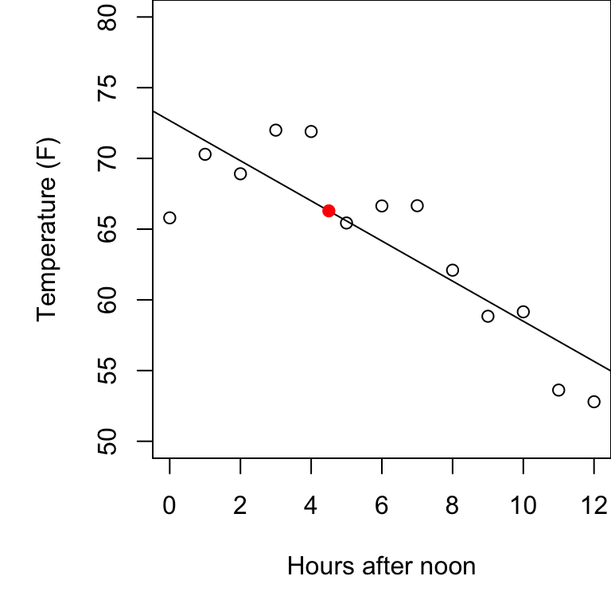

- Quadratic regression

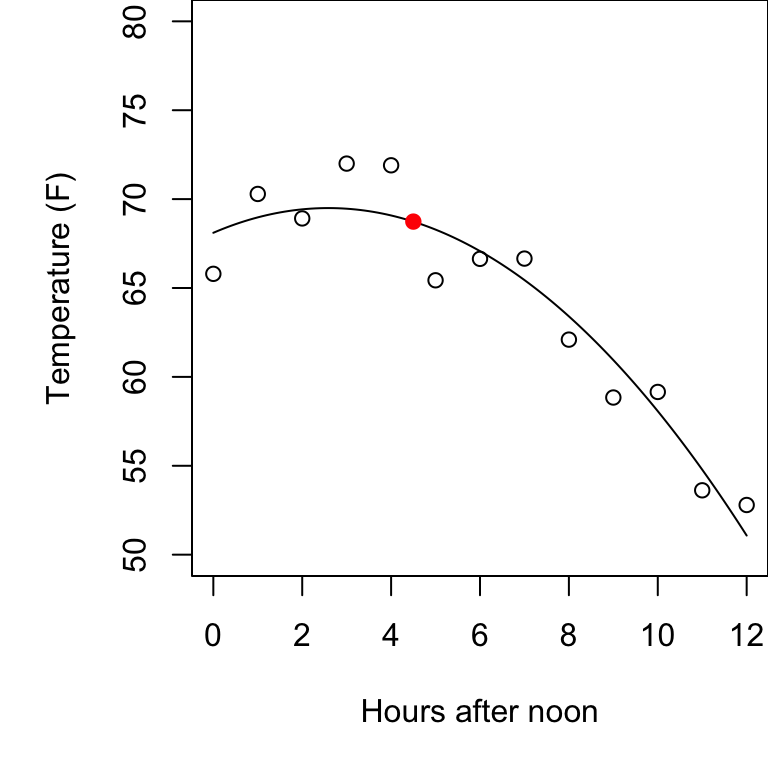

- Cubic regression

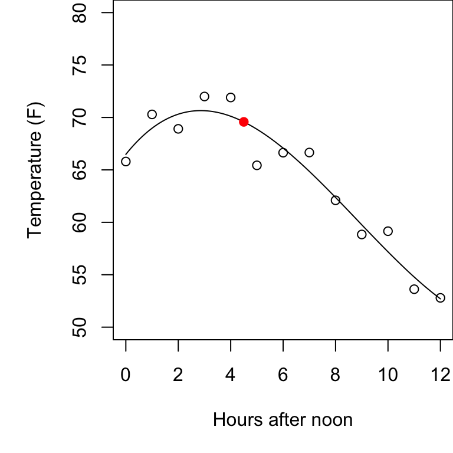